# SM for Brock et al. Progress in Physical Geography

James M.R. Brock, Finnbar Lee, John Wainwright, George L.W. Perry

11 February, 2022

Commented R code for analyses described in Brock et al. PiPG Progress reports

This document shows how to perform the analyses described in Brock et al. largely using the data from Lee et al. (2018) and Perry et al. (2010). It is *not* a detailed description of the methods themselves (for that see references in the main document) but rather an example of how to conduct the sorts of analyses mentioned in the article.

First we’ll load some packages necessary for the wrangling, visualisation and analyses.

```r
# load pacman package + install if missing - used to load/install multiple packages at once
if (!require("pacman")) install.packages("pacman")

# load packages + install any that are missing
pacman::p_load(tidyverse, broom, knitr, janitor, ggfortify, patchwork,
               mdthemes, vegan, analogue, ggvegan, mvabund, devtools)
```

```r
# install packages from GitHub (not available on CRAN)
devtools::install_github("phytomosaic/ecole")
devtools::install_github("phytomosaic/fitNMDS")
devtools::install_github("jfq3/ggordiplots")
devtools::install_github("pmartinezarbizu/pairwiseAdonis/pairwiseAdonis")
devtools::install_github("gavinsimpson/ggvegan")
```

```r
# load newly installed packages from GitHub
pacman::p_load(ecole, fitNMDS, ggordiplots, pairwiseAdonis, ggvegan)

# load custom functions for plotting ordinations from vegan
source("auxScripts/helperPlots.r")
```

# Load data

Load data we’ll explore and do some re-organising. We need to be a bit cautious because although base `R` and many multivariate analysis packages (e.g., `vegan`) use row names, the `tidyverse` (tibbles) does *not* as they don’t confirm to tidy data. Need to be aware of this when moving between the two.

First, load freshwater invertebrate, physiochemical and location data from Auckland, New Zealand from Lee et al. (2018)

```r
# Load data and tidy up
# invert abundances
inverts <- read.csv(file = "data/inverts_to_species.csv", row.names = 1)
# water chem at some sites
chem <- read.csv(file = "data/physicochemical.csv", row.names = 1)
# location data (WGS84 coords)
locations <- read.csv(file = "data/Site_Coords_WGS84.csv", row.names = 1)

invert_sites <- rownames(inverts)
chem_sites <- rownames(chem)

# standardise data
inverts_pa <- decostand(inverts, method = "pa")   # Presence-absence
inverts_l10 <- log10(inverts + 1)                 # log-10 transformed
inverts_hel <- decostand(inverts, method = "hel") # Hellinger transformed

# Get a subset of the water chemistry data
chem <- janitor::clean_names(chem)

# Only keep sit4s with invert data and remove some less useful variables
chem_sub <- chem[chem_sites %in% invert_sites,]
chem_sub <- select(chem_sub, -order, -land_form, -taxa, -qmci,
                   -mci, -ept, -proportion_ept, -gambusia)

# Subset of chemical data for hypothesis testing
chem_sub_hyp <- chem_sub %>%
  select(do, temperature, velocity, proportion_silt, proportion_macrophyte,
         proportion_riparian_cover20, pasture, din)

# Binary vectors for riparian cover and native cover
rip_cover <- chem_sub$proportion_riparian_cover0_5 > 0.2
native_cover <- chem_sub$native > 0.2
```

Second, load vegetation data from Aotea/Great Barrier Island (New Zealand) from Perry et al. (2010).

```r
# Load the Aotea veg data
# vegan uses row names, but the tidyverse doesn"t!
aotea <- read.csv(file = "Data/aotea_allyears_tidy.csv", row.names = 1)
aotea_pa <- decostand(aotea, method = "pa")           # convert to presence-absence
aotea_pa_nosing <- aotea_pa[,colSums(aotea_pa) > 1]   # PA without any singletons

# Make the site labels more useful
dfr <- data.frame(site = rownames(aotea_pa))
aotea_site <- separate(dfr, site, into = "code", "_") # ignore the warning
aotea_site$code <- str_sub(aotea_site$code, end = 2)
rm(dfr)
```

# Visualisation of the multivariate data

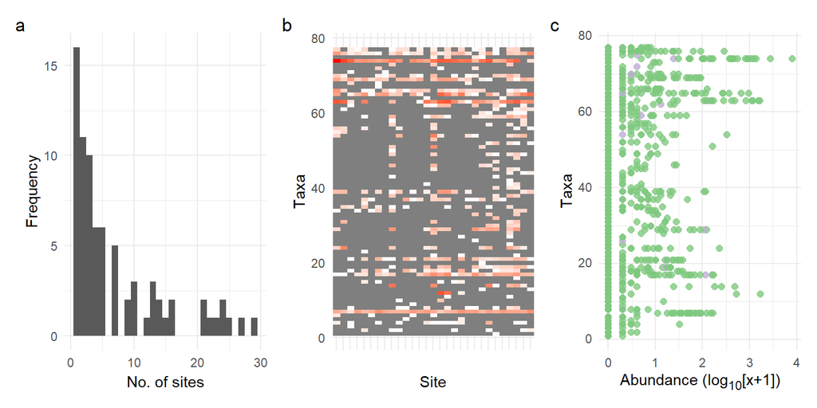

Histogram of number of sites each taxa occurs at (a). Heat map of abundance for species x site, grey = not present, white = low abundances and red = high abundnces (b). Dotplot of taxa abundances, replicating that in Wang et al. 2012 Methods Ecol Evol (c). All figures use the Lee et al. 2018 Invertebrate data

```r
# First, lengthen the data to make it easier for ggplot
aotea.long <- aotea %>%
  rownames_to_column(var = "site") %>%
  pivot_longer(cols = -site, names_to = "taxa", values_to = "abund")

inverts.long <- inverts %>%
  rownames_to_column(var = "site") %>%
  pivot_longer(cols = -site, names_to = "taxa", values_to = "abund")

# Histogram of number of sites each spp occurs at for Lee et al.
n.sites.iv <- data.frame(n = colSums(inverts > 0))

sites.hist.iv.gg <- ggplot(n.sites.iv) +
  geom_histogram(aes(x = n), binwidth = 1) +
  labs(x = "No. of sites", y = "Frequency") +
  theme_minimal()

# A heat map of abundance for species x site for Lee et al. data
inverts.long$taxa_num <- as.numeric(factor(inverts.long$taxa,
                                           levels = unique(inverts.long$taxa)))

heat.iv.gg <- ggplot(inverts.long, aes(x = site, y = taxa_num)) +
  geom_raster(aes(fill=log10(abund)), show.legend = FALSE) +
  scale_fill_gradient(low="grey99", high="red") +
  labs(x = "Site", y = "Taxa") +
  theme_minimal() +
  theme(axis.text.x=element_blank(),
        axis.ticks.x=element_blank())

# A dotplot to replicate that in Wang et al. 2012 Methods Ecol Evol
warton.iv <- data.frame(x = as.vector(as.matrix(inverts)),
                        y = rep(1:77, each = 29),
                        col = chem_sub$native > 0.4)

dot.wang.iv.gg <- ggplot(data = warton.iv) +
  geom_point(aes(x = log10(x+1), y = y, col = col),
             alpha = 0.8, size = 2, show.legend = FALSE) +
  scale_color_brewer(type = "qual") +
  labs(y= "Taxa", x = "Abundance (log<sub>10</sub>[x+1])") +
  theme(axis.text.x=element_blank(),
          axis.ticks.x=element_blank()) +
  md_theme_minimal()   # mdthemes lets us use markdown in graph notations

# combine plots
fig1 <- sites.hist.iv.gg + heat.iv.gg + dot.wang.iv.gg +
plot_annotation(tag_levels = "a")
```

Next, look at the mean-variance relationship in the two datasets - this is of concern in tests of location and dispersion, and adequately addressing it is central to model-based multivariate analysis (Warton *et al.* (2015)).

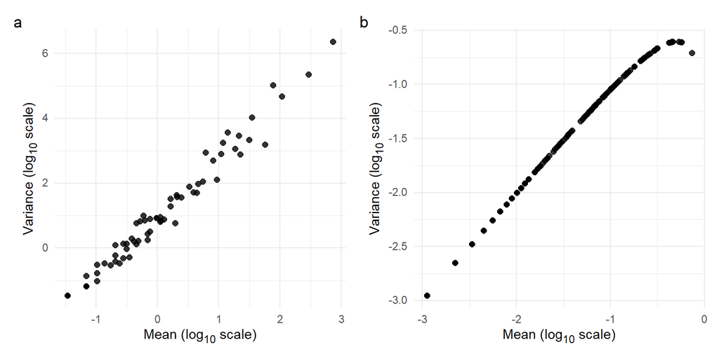

Mean-variance relationships for Lee et al. 2018 invertebrate (a) and Perry et al 2010 (b) vegetaion data.

```r
# freshwater invert data
# calculate mean and variance
inverts_mv <- data.frame(mean = colMeans(inverts),
                         var = apply(inverts , 2, var))

# plot
invert.mean.gg <- ggplot(data = inverts_mv) +
  geom_point(aes(x = log10(mean), y = log10(var)), alpha = 0.8, size = 2) +
  labs(y = "Variance (log<sub>10</sub> scale)",
       x = "Mean (log<sub>10</sub> scale)") +
  md_theme_minimal()

# Aotea vegetation data
# calculate mean and varaince
aotea_mv <- data.frame(mean = colMeans(aotea_pa),
                       var = apply(aotea_pa , 2, var))

# plot
veg.mean.gg <- ggplot(data = aotea_mv) +
  geom_point(aes(x = log10(mean), y = log10(var)), alpha = 0.8, size = 2) +
  labs(y = "Variance (log<sub>10</sub> scale)",
       x = "Mean (log<sub>10</sub> scale)") +
  md_theme_minimal()

# combine plots
fig2 <- invert.mean.gg + veg.mean.gg +
  plot_annotation(tag_levels = "a")
```

# Unconstrained ordination

## Methods of multidimensional scaling

### Lee et al. invertebrate data

Having visualised the data, we can look at some ways to explore it using multidimensional scaling as a means of dimensional reduction – these methods are available in the `vegan` package, which is extremely well documented and support by a series of [vignettes](https://cran.r-project.org/web/packages/vegan/). Here we are using the methods in an exploratory way, to generate hypotheses.

First, classical/metric MDS of the Lee et al. (2018) invertebrate data. In vegan we can do this either unweighted or weighted; below we do both with row sums as proportions of matrix sum as weights. Also, because we use a non-Euclidean distance metric there is a risk of negative eigenvalues, so we use the `add` argument. Using `eig = TRUE` returns the eigenvalues for us. Here, the weighted solution is strongly influence by a few sites with much higher abundance than others (e.g., F16 and F01).

```r
# Non-weighted using the Bray_Curtis
pcoa_iv <- wcmdscale(d = vegdist(inverts), eig = TRUE, add = "lingoes")

# get the weights (row sums)
wgt_iv <- iv <- rowSums(inverts)/sum(inverts)

 # Weighted
pcoa_wgt_iv <- wcmdscale(d = vegdist(inverts), w = wgt_iv, eig = TRUE, add = "lingoes")
```

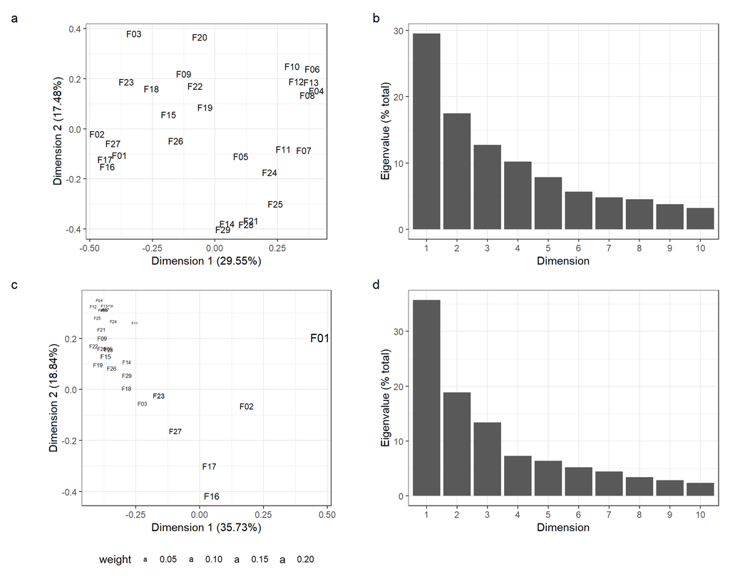

Unweighted metric MDS (a) and associated eigenvalues (b), weighted metric MDS (c) and associated eigenvalues (d) for Lee et al. 2018 Invertebrate data

```r
# Get the coordinates (using vegan::scores)
pcoa_scores <- data.frame(scores(pcoa_iv)[,1:2],
                          scores(pcoa_wgt_iv)[,1:2],
                          site = rownames(inverts),
                          w = wgt_iv) %>%
  rename(Dim1_wgt = Dim1.1, Dim2_wgt = Dim2.1)

# Get the eigenvalues and their proportional value
pcoa_eig <- data.frame(eig = pcoa_iv$eig[1:10],
                       expl = round(pcoa_iv$eig[1:10] / sum(pcoa_iv$eig[1:10]) * 100, 2))

pcoa_wgt_eig <- data.frame(eig = pcoa_wgt_iv$eig[1:10],
                           expl = round(pcoa_wgt_iv$eig[1:10] / sum(pcoa_wgt_iv$eig[1:10]) * 100, 2))

# Make some axis labels
xl <- paste("Dimension 1 (",pcoa_eig$expl[1], "%)", sep = "")
yl <- paste("Dimension 2 (", pcoa_eig$expl[2], "%)", sep = "")

xl_w <- paste("Dimension 1 (",pcoa_wgt_eig$expl[1], "%)", sep = "")
yl_w <- paste("Dimension 2 (", pcoa_wgt_eig$expl[2], "%)", sep = "")

## unweighted plot
pcoa.gg <- ggplot(pcoa_scores) +
  geom_text(aes(x = Dim1, y = Dim2, label = site), size = 3) +
  labs(x = xl,
       y = yl) +
  coord_equal() +
  theme_bw()

# eigenvalues plot
pcoa.eig.gg <- ggplot(pcoa_eig) +
  geom_bar(aes(x = as.factor(1:10), y = expl),
           stat = "identity") +
  labs(x = "Dimension",
       y = "Eigenvalue (% total)") +
  theme_bw()

## weighted plot
pcoa.wgt.gg <- ggplot(pcoa_scores) +
  geom_text(aes(x = Dim1_wgt, y = Dim2_wgt, label = site, size = w)) +
  scale_size_continuous(range  = c(1, 4)) +
  labs(x = xl_w,
       y = yl_w,
       size = "weight") +
  coord_equal() +
  theme_bw()

# eigenvalues plot
pcoa.eig.wgt.gg <- ggplot(pcoa_wgt_eig) +
  geom_bar(aes(x = as.factor(1:10), y = expl), stat = "identity") +
  labs(x = "Dimension",
       y = "Eigenvalue (% total)") +
  theme_bw()

# gather plots
fig3 <- pcoa.gg + pcoa.eig.gg + pcoa.wgt.gg + pcoa.eig.wgt.gg +
    plot_layout(widths = c(1, 1)) + plot_annotation(tag_levels = 'a') & theme(legend.position = 'bottom')
```

Second, look at non-metric multidimensional scaling. Remember that although nMDS and PCOA are both called ‘multidimensional scaling’ they are quite different in that nMDS works on ranks and is based on a stochastic (non-analytic) algorithm. We’ll start with the Lee et al. invertebrate data showing the nMDS and then fitting environmental vectors on it (commands `vegan::metaMDS` and `vegan::envfit`, respectively).

```r
# nMDS of the Lee et al. invertebrate data

# Bray-curtis distance matrix
invert_dist <- vegdist(inverts)

# Turn off automatic rescaling. Trace controls output verbosity
invert_mds <- metaMDS(invert_dist, autotransform = FALSE, trace = 1)

# Make the plots (using custom plot.mds.gg function from helperPlots.r)
iv.mds.gg <- plot.mds.gg(invert_mds, txt.x = -0.35,
                         txt.y = -0.35,labels = TRUE,
                         msl = 0.25)


# NOT USED - remove?

#nMDS coloured by native veg cover
# iv.mds_cluster.gg <- plot.mds.gg(invert_mds,
#                                  txt.x = -0.4, txt.y = -0.4,
#                                  clusters = native_cover)

# Shepperd plots (distance in nMDS vs distance in dissimilarity matrix)
# iv.shep.gg <- plot.shepp.gg(invert_dist, invert_mds)



# nMDS with points scaled in size by abundance of _Physa_
wgt <- inverts$Physa / 10
iv.bubble.gg <- plot.mds.bubble.gg(invert_mds, weights = wgt)

# Fit the chemical data as environmental vectors (envfit) and plot
iv_chem_fit <- envfit(invert_mds, chem_sub_hyp)
iv.fit.gg <- plot.envfit.gg(invert_mds, iv_chem_fit, p.max = .2,
                            clusters = native_cover)

# Or we could synthesis all the chem data with a PCA and fit those axes
chem_pca <- princomp(chem_sub, cor = TRUE)
chem_pca_scores <- scores(chem_pca)
iv_pca_fit <- envfit(invert_mds, chem_pca_scores[,1:8])

iv.fitpca.gg <- plot.envfit.gg(invert_mds,
                               iv_pca_fit,
                               p.max = .1,
                               clusters = native_cover)

# gather plots
fig4 <- (iv.mds.gg + iv.bubble.gg + iv.fit.gg + iv.fitpca.gg) +
  plot_annotation(tag_levels = "a") +
  plot_layout(ncol = 2, guides ="collect") &
  theme(legend.position = "bottom")
```

## plots need tidying

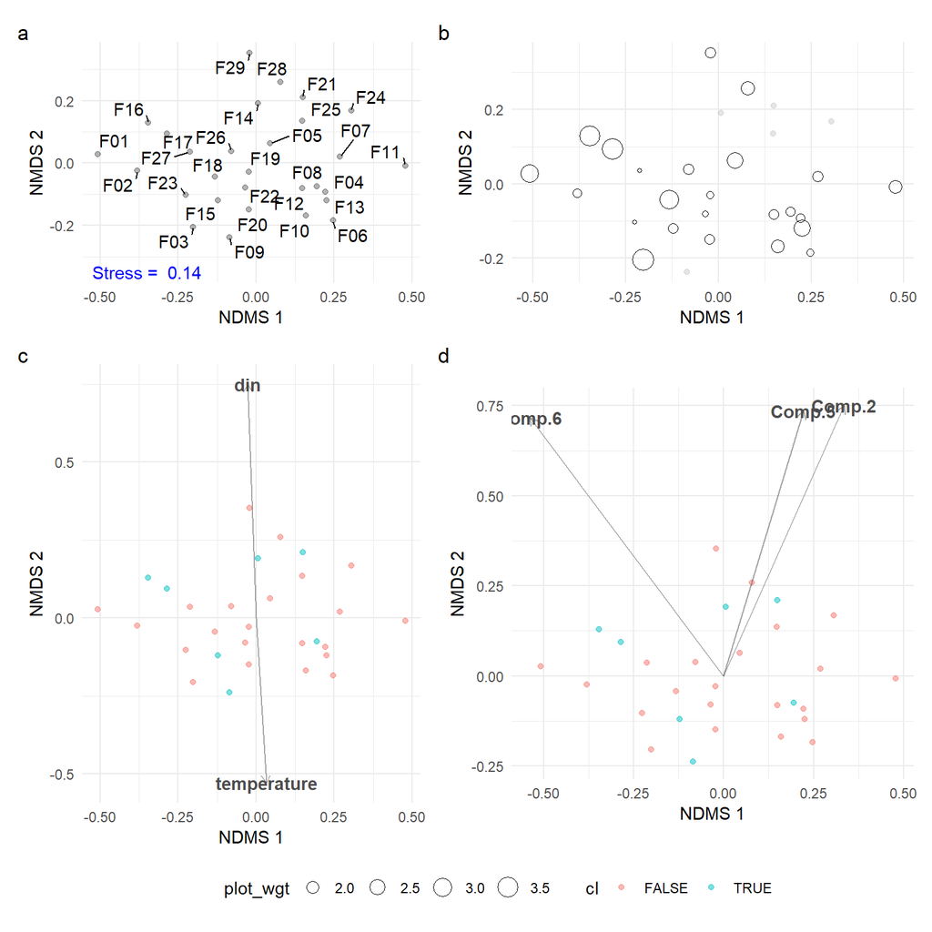

nMDS of invertebrate data (a), with point size scale by Physa (genus snails) abundance (b), and physiocemical data fit as environmental vectors (c), and with environmetal vectors fit using PCA axis of all physiochemical variables (d)

One issue with fitting vectors is that they may not depict non-linear relationships adequately (although they have the benefit of allowing multiple variables to be seen). An option is to fit a surface (e.g. via a spline or general additive model [GAM]) instead. Here, we fit DIN and the first component of the PCA to the invertebrate nMDS. As with any surface fitting exercise it is important to evaluate the effects of different parametrisations (e.g., the knots used in the GAM) via the underlying diagnostics.

## plots need tidying

```r
par(mfrow = c(2,2))

din_surf_k5 <- ordisurf(x = invert_mds, y = chem_sub$din,
                        knots = 5, main = "DIN, k = 5")

pca_surf_k5 <- ordisurf(x = invert_mds, y = chem_pca_scores[,1],
                        knots = 5, main = "PCA comp 1, k = 5")


din_surf_k10 <- ordisurf(x = invert_mds, y = chem_sub$din,
                         knots = 10, main = "DIN, k = 10")

pca_surf_k10 <- ordisurf(x = invert_mds, y = chem_pca_scores[,1],
                         knots = 10, main = "PCA comp 1, k = 10")
```

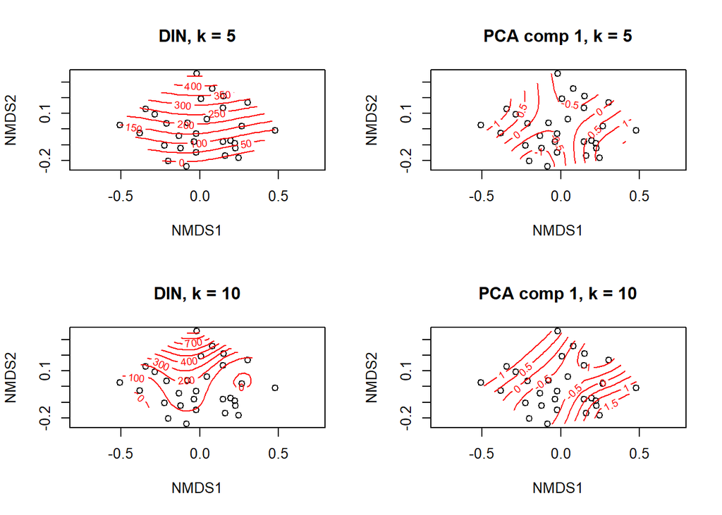

### Perry et al. vegetation data

Now we’ll do an nMDS of the Aotea vegetation data. Unlike the Lee et al. invertebrate data, this information is presence-absence only, and covers many more sites and species (895 x 273). Although it may seem obvious that presence-absence is less informative than abundance data, this is context-dependent. Wilson (2012) suggests that abundance data are more informative that presence-absence data (in ordinations) only where small extents are covered, the vegetation is reasonably homogeneous, and the abundance information is high-quality. This example may have some issues with finding a convergent solution - check the `vegan` help for details.

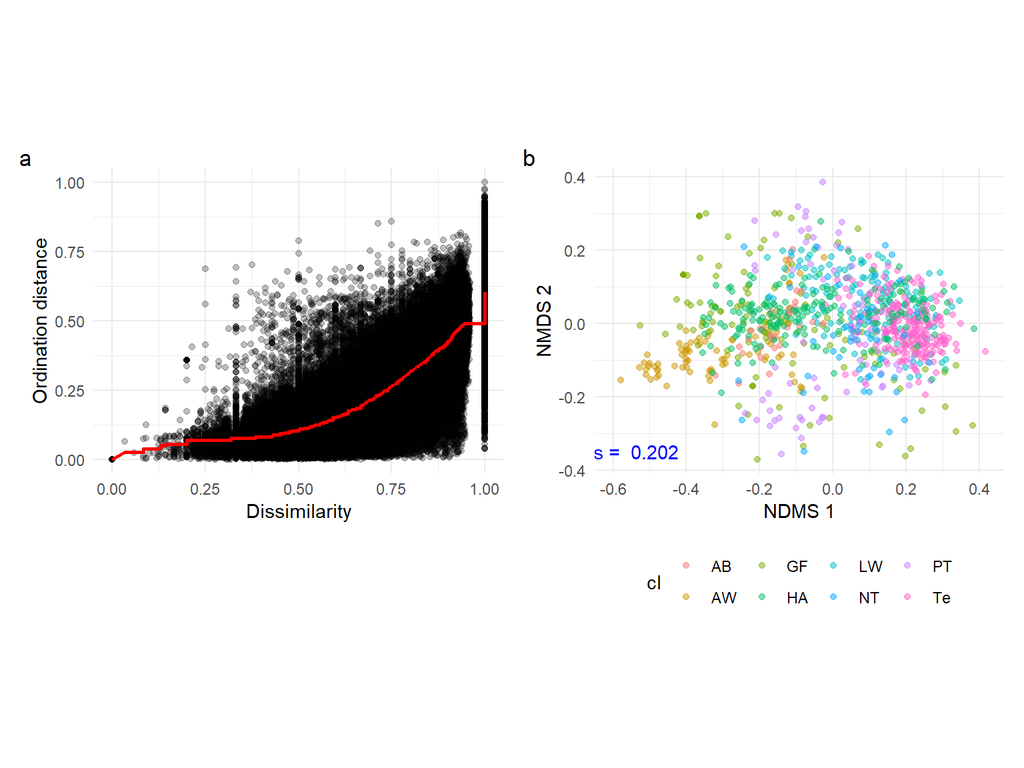

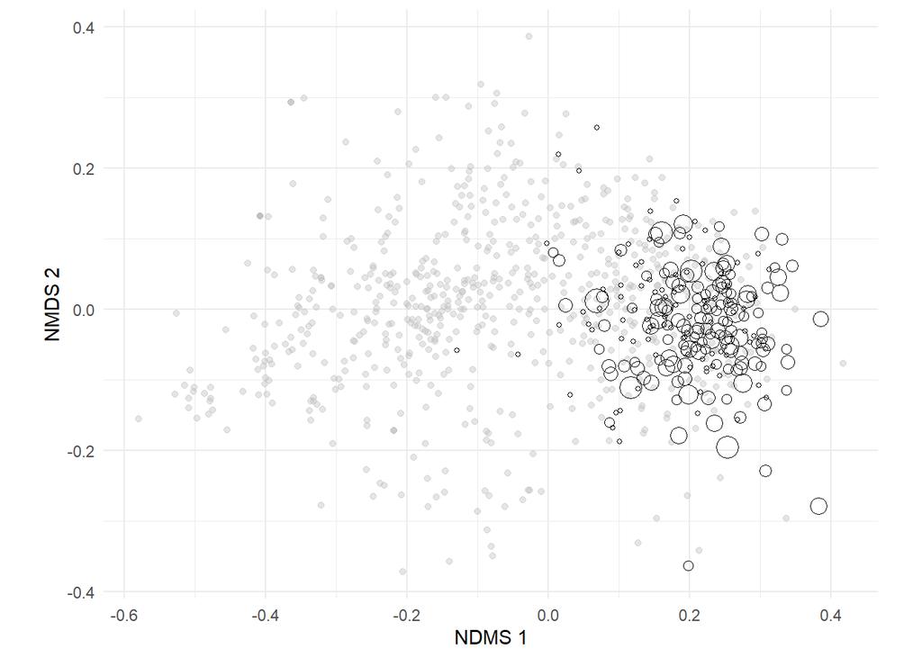

nMDS ordination of of vegetation data with point size scaled by the abundance of the late successional tree, *Beilschmiedia tawa*

## Principle response curves

Principle response curves seek to fit a smooth curve though some high dimensional space. They are probably most appropriate where there is a single dominant gradient (in time or space) (De’ath, 1999; Simpson & Birks, 2012). Here, we will apply it to the Lee et al. data, which is underpinned by a strong gradient in land-use, using the implementation in `analogue::prcurve`. The initial configuration can be quite important (see De’ath (1999)), so here we use the first axis of a correspondence analysis, with a GAM, and allow the complexity of the smoother to vary across species. We can show the fit of the curve at each iteration by setting `plotit = TRUE`.

```r
# Fit PRC here with the complexity fixed across all species (vary)
# The method here specifies the starting conditions (first axis of a method)
# Here we use a GAM as the smoother (slower than spline)
inverts_pc <- prcurve(inverts_l10, method = "ca", trace = TRUE,
                      vary = TRUE, smoother = smoothGAM,
                      penalty = 1.4)
```

```
##
##    Determining initial DFs for each variable...
##
##
##
## Fitting Principal Curve:
##
## Initial curve: d.sq: 341.848
## Iteration   1: d.sq: 221.398
## Iteration   2: d.sq: 201.251
## Iteration   3: d.sq: 196.651
## Iteration   4: d.sq: 195.267
## Iteration   5: d.sq: 195.143
##
## PC Converged in 5 iterations.
```

```r
inverts_pc
```

```
##
##  Principal Curve Fitting
##
## Call: prcurve(X = inverts_l10, method = "ca", smoother = smoothGAM,
## vary = TRUE, trace = TRUE, penalty = 1.4)
##
## Algorithm converged after 5 iterations
##
##           SumSq Proportion
## Total       342       1.00
## Explained   147       0.43
## Residual    195       0.57
##
## Fitted curve uses 563.023 degrees of freedom.
```

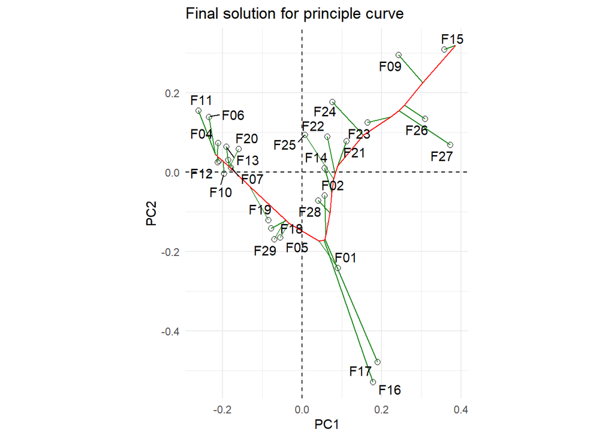

Principal response curve for the freshwater invertebrate dataset.

```r
plot.prcurve.gg(inverts_pc) +
  ggtitle("Final solution for principle curve")
```

We can see that the curve captures 43% of the variance but (say compared to a PCA) at the cost of a much more complex model. It is also possible to look at individual taxa response along the gradient identified in the principle curve. The command in analogue is `sppResponse`. Here, we have plotted the subset of taxa occurring at at least 17 (60%) of survey sites. Visually, we can see some taxa sorting along the gradient identified in the PC; some taxa respond curvilinearly (e.g., Chironomidae) but others show a threshold-type effect (e.g., Amphipods).

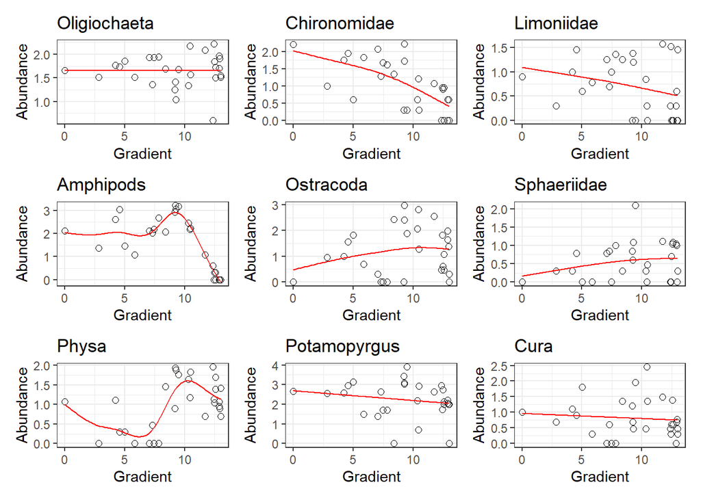

Principal response curve taxa rersponses for the freshwater invertebrate dataset.

```r
# taxa responses
invert_responses <- sppResponse(inverts_pc)

# subset common taxa (> 60% sites)
focal_spp <- chooseTaxa(inverts_l10, n.occ = 17, value = FALSE)

# plot
plot.sppResponse.gg(invert_responses, focal_spp = focal_spp)
```

## tsne and UMAP

# Constrained ordination

Now, we can move onto some methods of constrained ordination. First, a look at the ‘tikus’ dataset (measures of coral reef communities over time) to compare an unconstrained and a constrained (by time) ordination (data available in the `mvabund` package in R). Here, a distance-based redundancy analysis (`vegan::dbrda`) with an nMDS is presented. We will log-transform the data. This example is presented in detail in ver Braak and Šmilauer (-ter Braak & Šmilauer (2015)). Note that for the `metaMDS` we have increased the number of runs (*try*) and iterations (*maxit*) to help ensure convergence on an optimal solution.

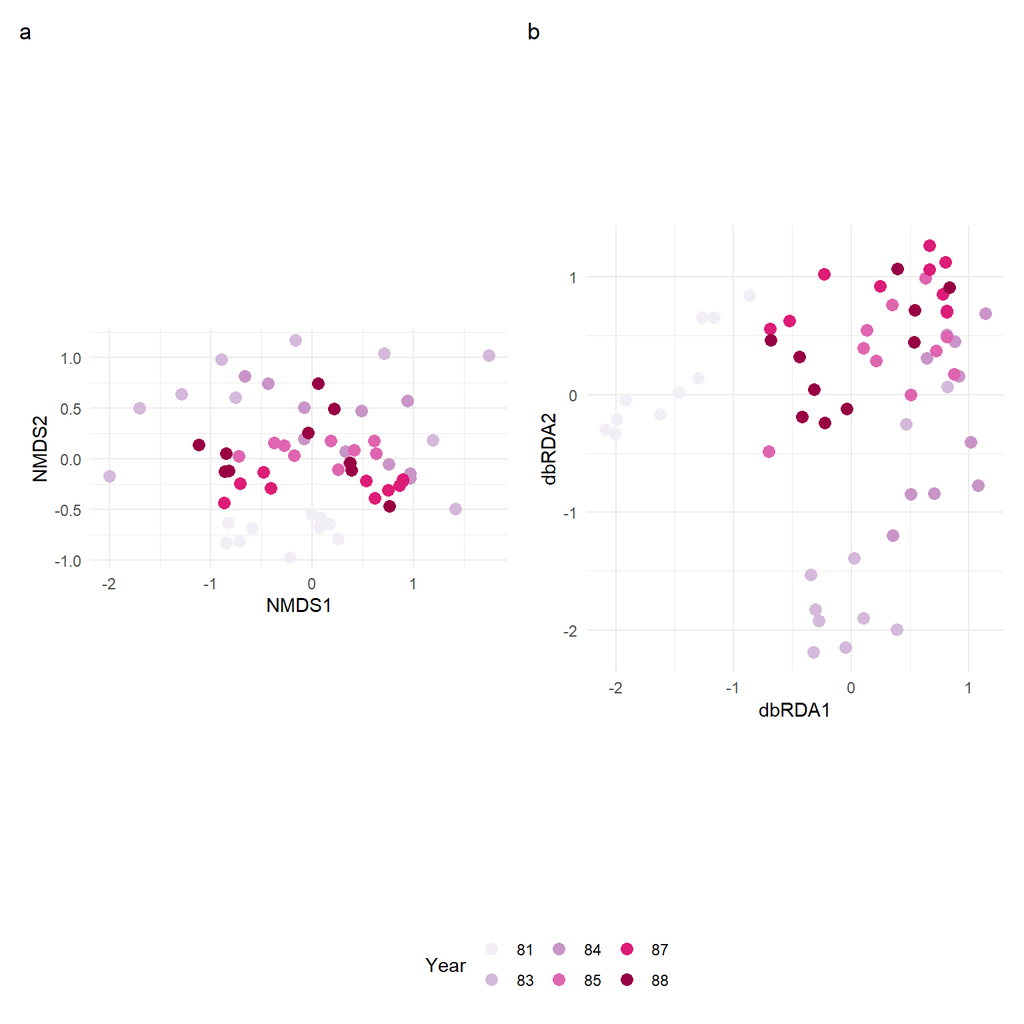

Uncontrained ordination of coral reef communities (a), and constrained (by time) ordination (b)

```r
# load data
data(tikus, package = 'mvabund')

# log transform
tikus_log <- log(tikus$abund + 1)
tikus_survey <- tikus$x$time

# Unconstrained ordination of the Tikus coral reef data
# nMDS - increased try and maxit for convergence
tikus_nmds <- metaMDS(tikus_log, autotransform = TRUE,
                      wascores = FALSE,
                      try = 100, maxit = 500, trace = 1)

# plot
tik.mds.gg <- ggplot(data = as.data.frame(scores(tikus_nmds))) +
  geom_point(aes(NMDS1, NMDS2, col = as.factor(tikus$x$time)), size = 3) +
  scale_color_brewer(name = "Year", palette = "PuRd") +
  coord_equal() +
  theme_minimal()

# Constrained (by time) ordination of the Tikus coral reef data
# Note use of formula notation
tikus_rd <- dbrda(tikus_log ~ tikus_survey, distance = "bray")
tikus_rd_scores <- data.frame(scores(tikus_rd)$sites)

#plot
tik.rd.gg <- ggplot(data = tikus_rd_scores) +
  geom_point(aes(dbRDA1, dbRDA2, col = as.factor(tikus_survey)), size = 3) +
  scale_color_brewer(name = "Year", palette = "PuRd") +
  coord_equal() +
  theme_minimal()

fig6 <- tik.mds.gg + tik.rd.gg +
    plot_annotation(tag_levels = "a") +
    plot_layout(guides = "collect", widths = c(1, 1)) &
    theme(legend.position = "bottom")
```

## RDA and CCA

A basic form of constrained analysis is redundancy analysis (RDA). We can do this using the command `vegan::rda`; note that if we do an RDA without any environmental variables we will have a PCA. Usually we will have two matrices; one describing the community at each site and the other the environmental variables (which constrain the ordination). The RDA in vegan allows use of a third matrix that can be partialled out (the ‘conditioning matrix’). We will do an RDA on a Hellinger transformed version of the Lee et al. data (transformed following the advice of Legendre & Gallagher (2001)).

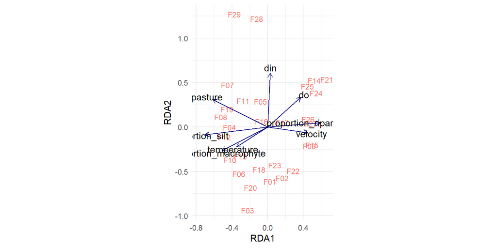

Constrained redundancy analysis (RDA) for freshwater invertebrate and physiochemical data.

```r
# RDA on subset of env data
invert_rda <- rda(inverts_hel ~ ., data = chem_sub_hyp)

# adjusted r2 (via the vegan package)
invert_rda_r2 <- round(RsquareAdj(invert_rda)$adj.r.squared, 3)

# Plot using ggvegan (as an example)
rda.iv.gg <- autoplot(invert_rda, layers = c("biplot", "sites"), geom = "text") +
  theme_minimal() +
  theme(legend.position = "none")
```

Now a canonical correspondence analysis (CCA) using the `vegan::cca` command. We’ll build two models on log_10_ transformed abundance data, one saturated and one using a subset of environmental predictors.

```r
invert_cca_all <- cca(inverts_l10, chem_sub)
invert_cca_red <- cca(inverts_l10, chem_sub_hyp)
```

Now we can plot the saturated and reduced model and compare them.

### plots need tidying

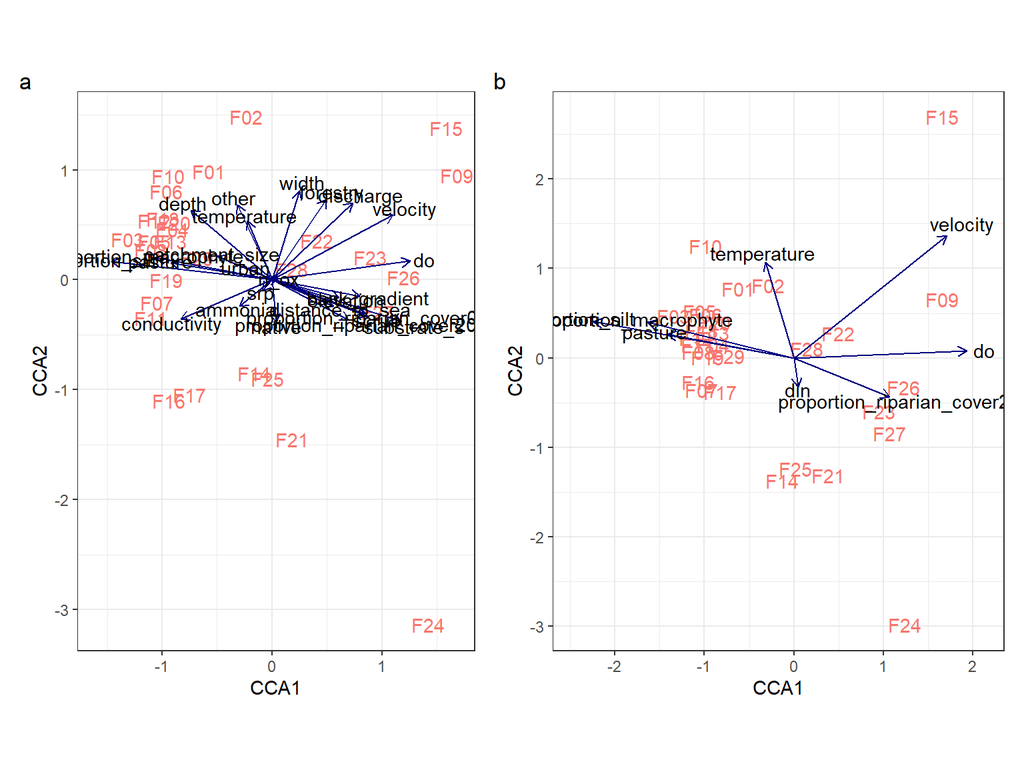

canonical correspondence analysis of freshwater invertebrate and environemntal data using all (a) and a subset (b) of environemtnal predictors.

```r
# Plot them - autoplot here is from ggvegan
invert.cca.all.gg <- autoplot(invert_cca_all, layers = c("biplot","sites"),
                              geom = "text") +
  theme_bw() +
  theme(legend.position = "none")

invert.cca.red.gg <- autoplot(invert_cca_red, layers = c("biplot","sites"),
                              geom = "text") +
  theme_bw() +
  theme_bw() +
  theme(legend.position = "none")

(invert.cca.all.gg + invert.cca.red.gg) +
  plot_annotation(tag_levels = "a")
```

## Distance-based RDA

dbRDA is similar to RDA but is designed to support a broader range of dissimilarity metrics (including some of those frequently used by community ecologists). Note that in vegan there are two versions, `capscale` (following Legendre and Anderson (1999)) and `dbrda` (following McArdle & Anderson (2001)). These differ in some implementation details (read the help!). Here we will use `capscale` to look at the Lee et al. invertebrate data.

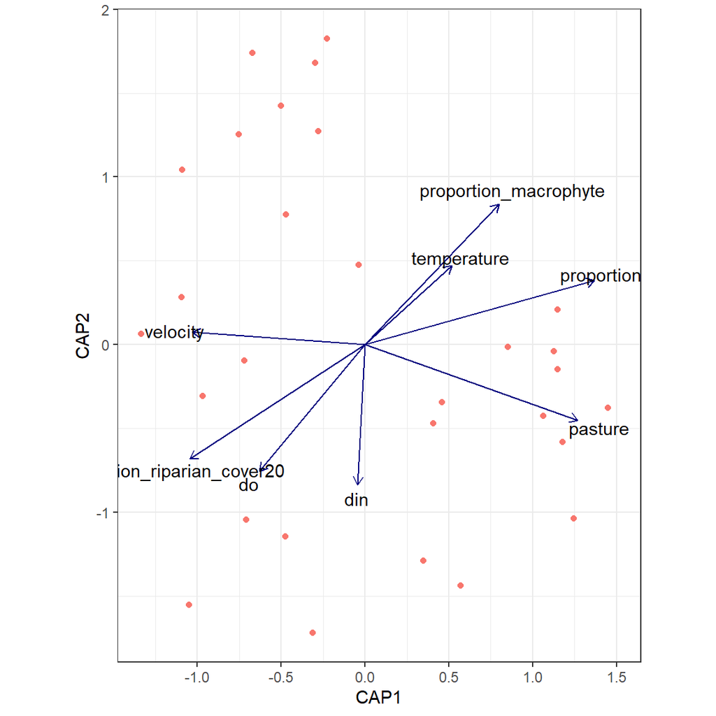

dbRDA of freshwater invertebrate and enviromental data

```r
invert_dbrda <- capscale(inverts ~ ., chem_sub_hyp, dist="bray")
dbrda.invert.gg <- autoplot(invert_dbrda, layers = c('sites', 'biplot')) +
  theme_bw() +
  theme(legend.position = 'none')

dbrda.invert.gg
```

## Variable selection and axis selection

For constrained ordinations it is possible to use various selection methods to assess the importance of individual variables and the significance of the axes. This can be done using forward, backward or stepwise model selection based on R<sup>2</sup> or AIC; each of these come with *caveats*., For example, the vegan help for `ordistep` pithily notes, “… constrained ordination methods do not have AIC, and therefore the step may not be trusted.” It is important to understand the various options available when conducting these (and any) analysis.

```r
full_mod_dbrda <- capscale(inverts_hel ~ ., data = chem_sub_hyp, dist = "bray")  # full model
null_mod_dbrda <- capscale(inverts_hel ~ 1, data = chem_sub_hyp, dist = "bray")  # intercept-only model

sel_mod_dbrda <- ordistep(null_mod_dbrda,
                          scope = formula(full_mod_dbrda),
                          direction = "both",
                          permutations = how(nperm = 499), trace = FALSE )


anova(sel_mod_dbrda)
```

|  | Df | SumOfSqs | F | Pr(>F) |
| --- | --- | --- | --- | --- |
| Model | 2 | 1.215544 | 4.523046 | 0.001 |
| Residual | 26 | 3.493678 | NA | NA |

```r
full_mod_dbrda_r2 <- round(RsquareAdj(full_mod_dbrda)$adj.r.squared, 3)
sel_mod_dbrda_r2 <- round(RsquareAdj(sel_mod_dbrda)$adj.r.squared, 3)


dbrda.full.gg <- autoplot(full_mod_dbrda, layers = c("sites", "biplot"), geom = "text") +
  theme_minimal() +
  theme(legend.position = 'none')

dbrda.sel.gg <- autoplot(sel_mod_dbrda, layers = c("sites", "biplot"), geom = "text") +
  theme_minimal() +
  theme(legend.position = 'none')
```

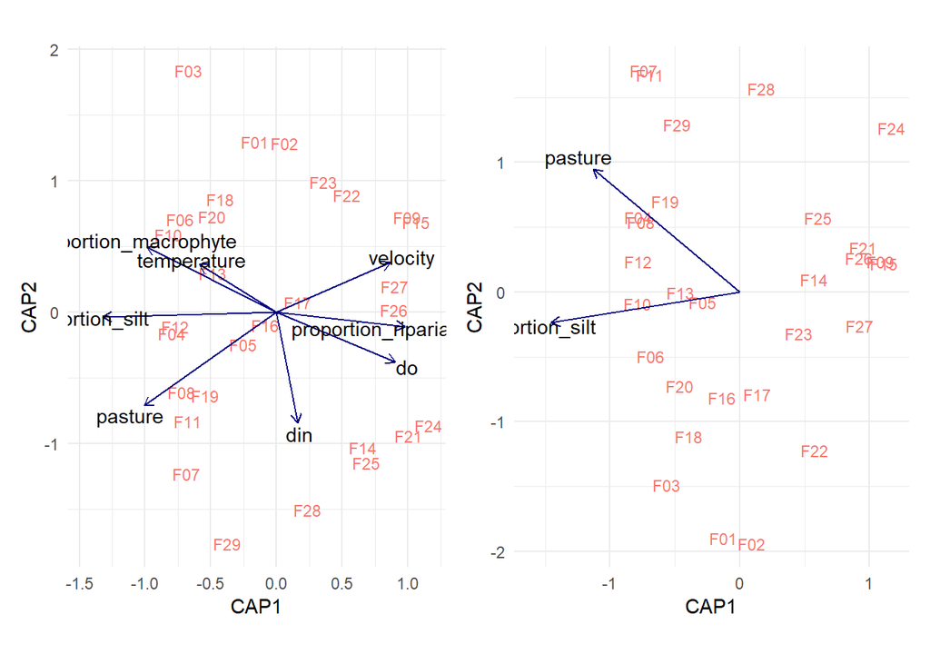

dbRDA including all hypothesised predictors, Adjusted R2 = 0.257 (a)and a subset based on model selection, Adjusted R2 = 0.213 (b)

```r
dbrda.full.gg + dbrda.sel.gg +
  plot_layout(guides = "collect")
```

In a similar vein, we can look at the significance of each variable or axis (again, using `vegan::anova.cca`). This command uses a permutation-based approach (see Legendre et al. (2011)). As an example, we will use RDA on the Hellinger-transformed invertebrate data.

```r
full_mod <- rda(inverts_hel ~ ., chem_sub_hyp) # Model with all explanatory variables

mod_aov <- anova(full_mod)  # This is a test for the overall model
term_aov <- anova(full_mod, by = "term") # can also do marginal tests - see vegan help
axis_aov <- anova(full_mod, by = "axis")

mod_aov  # Model is significant
```

|  | Df | Variance | F | Pr(>F) |
| --- | --- | --- | --- | --- |
| Model | 8 | 0.1652021 | 1.750904 | 0.005 |
| Residual | 20 | 0.2358811 | NA | NA |

```r
term_aov # look for significant terms
```

|  | Df | Variance | F | Pr(>F) |
| --- | --- | --- | --- | --- |
| do | 1 | 0.031037953 | 2.6316608 | 0.012 |
| temperature | 1 | 0.020733551 | 1.7579662 | 0.093 |
| velocity | 1 | 0.026393307 | 2.2378482 | 0.024 |
| proportion_silt | 1 | 0.028966366 | 2.4560141 | 0.022 |
| proportion_macrophyte | 1 | 0.012253999 | 1.0389979 | 0.400 |
| proportion_riparian_cover20 | 1 | 0.006752344 | 0.5725209 | 0.794 |
| pasture | 1 | 0.023681180 | 2.0078911 | 0.054 |
| din | 1 | 0.015383418 | 1.3043365 | 0.259 |
| Residual | 20 | 0.235881111 | NA | NA |

```r
axis_aov # and axes
```

|  | Df | Variance | F | Pr(>F) |
| --- | --- | --- | --- | --- |
| RDA1 | 1 | 0.070096633 | 5.9433867 | 0.004 |
| RDA2 | 1 | 0.036737529 | 3.1149191 | 0.423 |
| RDA3 | 1 | 0.019958252 | 1.6922298 | 0.904 |
| RDA4 | 1 | 0.016729927 | 1.4185050 | 0.913 |
| RDA5 | 1 | 0.010418070 | 0.8833323 | 0.987 |
| RDA6 | 1 | 0.004855654 | 0.4117035 | 1.000 |
| RDA7 | 1 | 0.003337448 | 0.2829771 | 1.000 |
| RDA8 | 1 | 0.003068604 | 0.2601823 | 0.988 |
| Residual | 20 | 0.235881111 | NA | NA |

# Recent advances

## Resampling assessment of ordinations

```r
# Define number of simulations to do - slow for large data but could parallelise!
# We'll use fitNDMS::resamp_ndms to do this.  BS is the bootstrap size and
# B the no., of sims. Underneath it is using vegan::metaMDS

nsims_iv <- 199
nsims_aotea <- 5  # need more for analysis but this is **slow**!

# Because this is slow we'll cache the op in a directory called 'rds'
  if (file.exists("rds/invert_resamp.rds")) {
      b_iv <- readRDS("rds/invert_resamp.rds") } else {
      set.seed(1767283)    # set seed for reproducibility
      b_iv <- resamp_nmds(inverts, BS = nrow(inverts) * 0.8, B = nsims_iv, k = 2)
      saveRDS(b_iv, "rds/invert_resamp.rds")
  }

  # as per above need to check convergence...
  if (file.exists("rds/aotea_resamp.rds")) {
      b_aotea <- readRDS("rds/aotea_resamp.rds") } else {
      set.seed(4337659)
      b_aotea <- resamp_nmds(aotea_pa, BS = nrow(aotea_pa) * 0.8, B = nsims_aotea, k = 2)
      saveRDS(b_aotea, "rds/aotea_resamp.rds")
      }

# Code here will trigger some warnings re expected pieces and coercion - can ignore
# Note that the number of times a site is sampled will not necessarily equal n_sims
# It is c. 0.8 x sims

  b_iv_dfr <- data.frame(b_iv$points) %>%
    rownames_to_column(var = 'site') %>%
    arrange(site) %>%
    separate(site, into = c('site', 'rep'), sep = "\\.") %>%
    mutate(rep = as.numeric(rep)) %>%
    mutate(rep = if_else(is.na(rep), 1 , as.numeric(rep) + 1))
  # TO DO - this might need checking
  b_aotea_dfr <- data.frame(b_aotea$points) %>%
    rownames_to_column(var = 'pcq.site') %>%
    arrange(pcq.site) %>%
    separate(pcq.site, into = c('pcq_point', 'rep'), sep = "\\.") %>%
    mutate(site = gsub("_.*","", pcq_point)) %>%
    mutate(rep = if_else(is.na(rep), 1 , as.numeric(rep) + 1))
```

```r
resamp.iv.gg <- plot.resamp(b_iv_dfr)
resamp.aotea.gg <- plot.resamp(b_aotea_dfr, legend = TRUE)

resamp.iv.stress.gg <- ggplot(data = data.frame(s = b_iv$stresses)) +
  geom_histogram(aes(s), bins = 20) + labs(x = 'Stress', y = 'Frequency') +
  theme_minimal()

resamp.aotea.stress.gg <- ggplot(data = data.frame(s = b_aotea$stresses)) +
  geom_histogram(aes(s), bins = 10) +
  labs(x = 'Stress', y = 'Frequency') +
  theme_minimal()
```

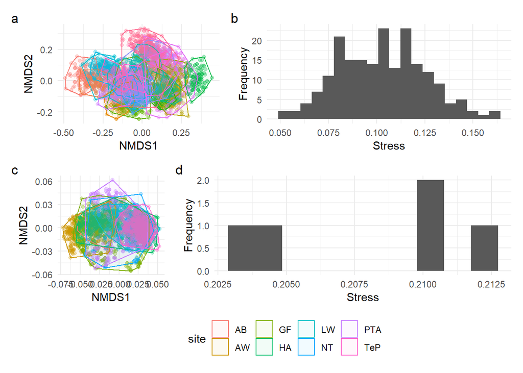

```r
(resamp.iv.gg + resamp.iv.stress.gg) / (resamp.aotea.gg + resamp.aotea.stress.gg) +
  plot_annotation(tag_level = 'a') +
  plot_layout(guides = "collect") &
  theme(legend.position = 'bottom')
```

## Trajectory analysis

Neither the invertebrate nor vegetation data we have used are suitable for trajectory analysis. To conduct trajectory analysis in R you can use the ecotraj library - it is support by an excellent [vignette](https://cran.r-project.org/web/packages/ecotraj/vignettes/IntroductionETA.html) and some sample data.

## Tests of location and dispersion

Often when conducting an unconstrained ordination we have information about *a priori* groups or explanatory variables for each site. We emphasise the *a priori* as there is a risk of circularity in using ordination to identify groups and then assessing whether they differ from each other. There are two questions we might ask: (i) do these groups differ in their location, and (ii) do the groups differ in their scatter (‘dispersion’). The first question would allow us to assess whether there have been shifts in community structure under different management regimes, for example; the second, is relevant where there may not be a change but a site is winnowed out to a subset of some other reference community (e.g. under invasion). Most of these methods are permutation-based (meaning we can use parallelisation to speed thigns uo) and operate on the dissimilarity matrix rather than an ordination. We’ll use the Aotea data to demonstrate these methods as we have groups (geographic locations).

```r
 # reduce if you want to speed up!
n_perm <- 499
n_cores <- parallel::detectCores() - 1      # cores for parallelisation (set to 1 for none)

aotea_dist <- vegdist(aotea_pa, method = "bray")

# ANOSIM on 'site
aotea_anosim <-anosim(aotea_dist, aotea_site$code, permutations = n_perm, parallel = n_cores)

# PERMANOVA on 'site'
aotea_adonis <- adonis2(aotea_dist ~ aotea_site$code, permutations = n_perm, parallel = n_cores)

# You can't do pairwise comparisons in adonis2 but the pairwiseAdonis pakcage allows this
### TO DO

# Test for homogeneity of variance (scatter)
aotea_mod <- betadisper(aotea_dist, aotea_site$code)
aotea_mod_perm <- permutest(aotea_mod, pairwise = TRUE, permutations = n_perm)
aotea_mod_HSD <- TukeyHSD(aotea_mod)
```

```r
# permuted stats
aotea_perm_dfr <- data.frame(perm = c(permustats(aotea_anosim)$permutations,
                                permustats(aotea_adonis)$permutations),
                                test = rep(c('ANOSIM', 'PERMANOVA'), each = 499))

# observed stat (for comparison)
aotea_stat_dfr <- data.frame(stat = c(permustats(aotea_anosim)$statistic,
                                      permustats(aotea_adonis)$statistc),
                            test = c('ANOSIM', 'PERMANOVA'))
```

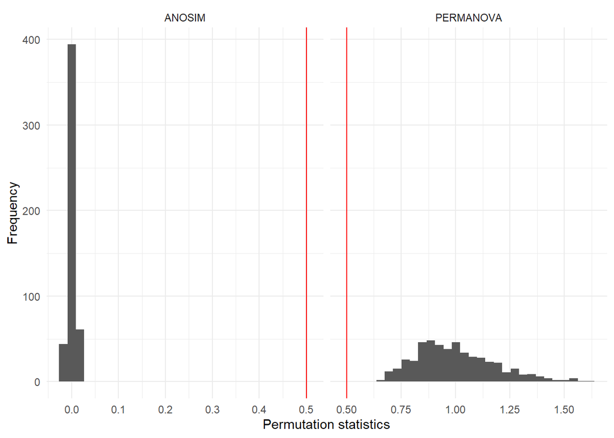

```r
aotea.sim.gg <- ggplot(aotea_perm_dfr) +
  geom_histogram(aes(x = perm)) +
  geom_vline(data = aotea_stat_dfr, aes(xintercept = stat), col = 'red') +
  facet_wrap(~test, scales = 'free_x') +
  labs (x = 'Permutation statistics', y = 'Frequency') +
  theme_minimal()


aotea.sim.gg
```

```r
aotea.adonis.td <- tidy(aotea_adonis)
```

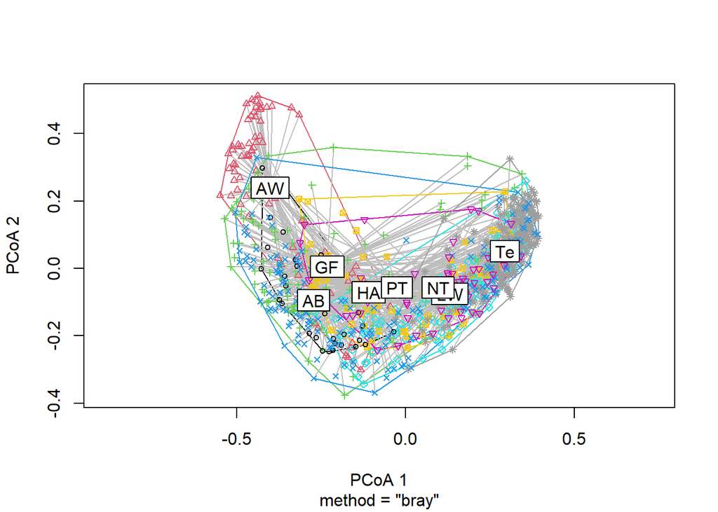

```r
disp.rc.plot <- plot(aotea_mod, main = "")
```

As discussed in the main text, ecological community data can have strong mean-variance relationships (Warton *et al.*, 2015). Model-based approaches to multivariate analysis are a direct response to this issue. One way to address this problem is a transformation of the data to down-weight abundant species (e.g. log-transform). Clarke et al (2006) describe a method that individually weights species based on their departure from a Poisson (mnean = variance) distribution.

```r
inverts_dispw <- dispweight(inverts)   # vegan::dispweight implements the method

iv_var <- apply(inverts, 2, var)
iv_mean <- apply(inverts, 2, mean)
iv_sig <- as.factor(ifelse(attr(inverts_dispw, "p") < 0.01, 1, 2))
iv_dfr <- data.frame(m = iv_mean, v = iv_var, s = iv_sig)

mv.raw.iv <- ggplot(iv_dfr) +
  geom_point(aes(x = m , y = v, size = m /v, col = s)) +
  geom_abline(slope = 1, intercept = 0) +
  scale_x_log10() +
  scale_y_log10() +
  labs(x = "Mean abundance", y = "Var. abundance") +
  theme_bw()

invert_wgt_mds <- metaMDS(inverts_dispw, distance = 'bray', autotransform = FALSE, trace = 1)
```

```
## *** No convergence -- monoMDS stopping criteria:
##     18: stress ratio > sratmax
##      2: scale factor of the gradient < sfgrmin
```

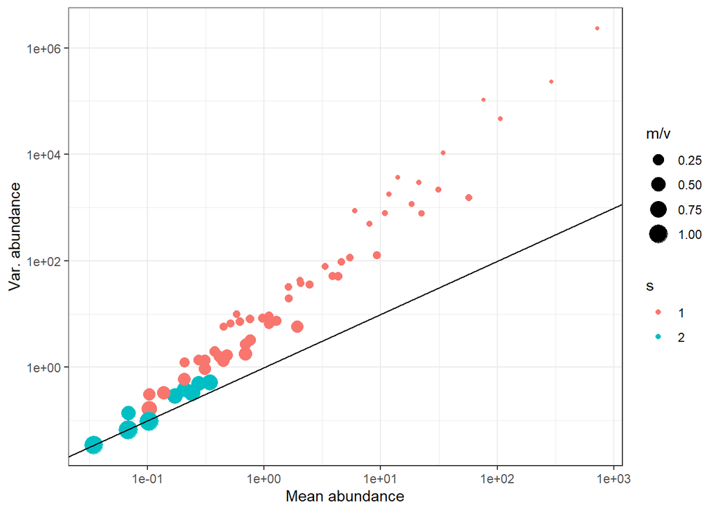

```r
iv.mds_wgt.gg <- plot.mds.gg(invert_wgt_mds, txt.x = -0.9, txt.y = -0.8, labels = TRUE)

(mv.raw.iv)
```

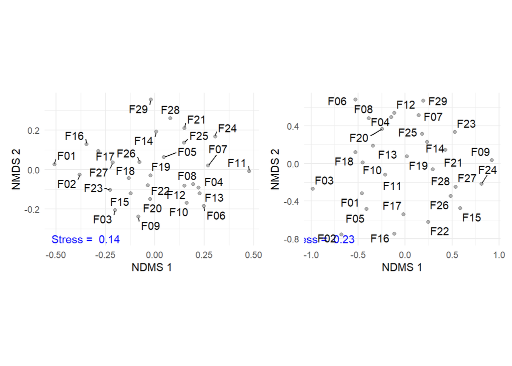

```r
(iv.mds.gg + iv.mds_wgt.gg)
```

## SIMPER and Indicator species

Finally, we might want to identify the species (or variable) that characterise specific groups. One commonly employed method to so this is SIMPER (for Brya-Curtis data). This method, however, tends to conflate changes in species mean and variance across groups and so may pick out the most variable (see Warton et al. (2012)). We’ll try it on the Aotea vegetation data to look at what species might contribute to differences between geographic locations.

```r
simper_veg <- simper(aotea_pa, group = aotea_site$code)
# simper_veg
```

The function provides much information that we need to sift through (not printed out here), but we can see which species contribute most to differences between groups. We need to use permutation to assess these differences more robustly.

```r
if (file.exists("rds/aotea_simper_perm.rds")) {
  aotea_mds <- readRDS("rds/aotea_simper_perm.rds") } else {
  n_cores <- parallel::detectCores() - 1
  n_perm <-19
  simper_perm_veg <- simper(aotea_pa, group = aotea_site$code, permutations = n_perm, parallel = n_cores, trace = FALSE)

  saveRDS(aotea_mds, "rds/aotea_simper_perm.rds")
  }


# summary(simper_perm_veg)
```

A different, and potentially more robust, approach is to use the indicator analysis descrined by de Caceres and colleagues (2009; 2010). This method seeks to identify ‘faithful’ species - in other words, those species that if present enable you to confidently determine the vegetation type (or types). The `indicspecies` package implements this approach, building on the work of Dufrêne and Legendre (1997).

```r
library(indicspecies)
n_perm <- 99
aotea_indic <- multipatt(aotea_pa, aotea_site$code, control = how(nperm = n_perm))
summary(aotea_indic, indvalcom = TRUE, alpha = 0.01) # summarise, showing A and B for species with p <= .01
```

```
##
##  Multilevel pattern analysis
##  ---------------------------
##
##  Association function: IndVal.g
##  Significance level (alpha): 0.01
##
##  Total number of species: 273
##  Selected number of species: 144
##  Number of species associated to 1 group: 66
##  Number of species associated to 2 groups: 29
##  Number of species associated to 3 groups: 13
##  Number of species associated to 4 groups: 14
##  Number of species associated to 5 groups: 15
##  Number of species associated to 6 groups: 6
##  Number of species associated to 7 groups: 1
##
##  List of species associated to each combination:
##
##  Group AB  #sps.  5
##              A       B  stat p.value
## Rubcis 0.55760 0.61765 0.587    0.01 **
## Pinpin 0.91924 0.26471 0.493    0.01 **
## Hellan 0.72072 0.17647 0.357    0.01 **
## Droaur 1.00000 0.08824 0.297    0.01 **
## Polmyr 1.00000 0.05882 0.243    0.01 **
##
##  Group AW  #sps.  21
##                     A      B  stat p.value
## Schten         0.9201 0.6250 0.758    0.01 **
## Moraff         0.7847 0.6375 0.707    0.01 **
## Gonagg         0.9798 0.3750 0.606    0.01 **
## Erilus         0.7372 0.4000 0.543    0.01 **
## Eribac         1.0000 0.2875 0.536    0.01 **
## Pomamo         0.7924 0.2750 0.467    0.01 **
## Gahlac         0.6067 0.2750 0.408    0.01 **
## Linlin         1.0000 0.1375 0.371    0.01 **
## PinusSpp       1.0000 0.1375 0.371    0.01 **
## Baujun         1.0000 0.1000 0.316    0.01 **
## Cyafra         1.0000 0.0875 0.296    0.01 **
```

[output cut: 268 more lines]

```
##  Group AB+HA+LW+NT+PT+Te  #sps.  2
##             A      B  stat p.value
## Myraus 0.9063 0.6254 0.753    0.01 **
## Freban 1.0000 0.2332 0.483    0.01 **
##
##  Group GF+HA+LW+NT+PT+Te  #sps.  2
##             A      B  stat p.value
## Vitluc 1.0000 0.1729 0.416    0.01 **
## Aspobl 1.0000 0.1050 0.324    0.01 **
##
##  Group AB+AW+GF+HA+LW+NT+PT  #sps.  1
##             A      B  stat p.value
## Kunrob 0.9719 0.7031 0.827    0.01 **
## ---
## Signif. codes:  0 '***' 0.001 '**' 0.01 '*' 0.05 '.' 0.1 ' ' 1
```

If we want to hone in on indicator taxa for specific groups then we can use the `indicators` function. For example, we could identify indicators (here just pairs) for the community at the Awana (‘AW’) site (the earliest in the succession). We can constrain so that *A* and *B* are above some threshold.

```r
awana_indicators <- indicators(aotea_pa, cluster = aotea_site$code, group = "AW", At = 0.7, Bt = 0.3, max.order = 2, verbose = TRUE) # set verbose FALSE to turn off the output
```

[output not shown]

[output cut: 225 more lines]

[output not shown]

```r
summary(awana_indicators)
```

```
## Result of 'indicators()':
##
##   Number of plots in target site group: 80
##   Number of candidate species: 273
##   Number of species used in combinations: 273
##   Number of indicators (single species or species combinations) kept: 25
##   Group coverage: 81.25%
```

```r
print(awana_indicators)
```

```
##                       A      B    sqrtIV p.value
## Lepsco+Schten 0.9090909 0.6250 0.7537784   0.005
## Schten        0.8771930 0.6250 0.7404361   0.005
## Olefur+Schten 0.9318182 0.5125 0.6910549   0.005
## Lepsco+Moraff 0.7391304 0.6375 0.6864369   0.005
## Moraff+Pteesc 0.9512195 0.4875 0.6809695   0.005
## Moraff+Schten 0.9736842 0.4625 0.6710655   0.005
## Pteesc+Schten 0.9736842 0.4625 0.6710655   0.005
## Hakser+Moraff 0.9047619 0.4750 0.6555623   0.005
## Leplat+Schten 0.9047619 0.4750 0.6555623   0.005
## Leufas+Schten 0.8510638 0.5000 0.6523281   0.005
## Hakser+Schten 0.9705882 0.4125 0.6327461   0.005
## Gonagg        0.9677419 0.3750 0.6024145   0.005
## Gonagg+Lepsco 0.9677419 0.3750 0.6024145   0.005
## Gonagg+Schten 1.0000000 0.3375 0.5809475   0.005
## Erilus+Schten 0.9642857 0.3375 0.5704791   0.005
## Gonagg+Olefur 1.0000000 0.3250 0.5700877   0.005
## Moraff+Olefur 0.7058824 0.4500 0.5636019   0.005
## Erilus+Pteesc 0.9032258 0.3500 0.5622535   0.005
## Gonagg+Leufas 1.0000000 0.3125 0.5590170   0.005
## Erilus+Moraff 0.7948718 0.3875 0.5549890   0.005
## Leplat+Moraff 0.7948718 0.3875 0.5549890   0.005
## Coprha+Schten 0.8484848 0.3500 0.5449493   0.005
## Gonagg+Leplat 0.9600000 0.3000 0.5366563   0.005
## Leplat+Pteesc 0.7209302 0.3875 0.5285456   0.005
## Schten+Kunrob 0.8181818 0.3375 0.5254868   0.005
```

We can estimate confidence limits for these values as well

```r
n_boot <- 19
awana_indicators_boot <- indicators(aotea_pa, cluster = aotea_site$code, group = "AW", At = 0.7, Bt = 0.3, max.order = 2, nboot.ci = n_boot, verbose = FALSE) # set verbose FALSE to turn off the output

summary(awana_indicators_boot)
```

```
## Result of 'indicators()':
##
##   Number of plots in target site group: 80
##   Number of candidate species: 273
##   Number of species used in combinations: 273
##   Number of indicators (single species or species combinations) kept: 25
##   Group coverage: 81.25%
```

```r
print(awana_indicators_boot$A) # check out the A values
```

```
##                    stat   lowerCI   upperCI
## Coprha+Schten 0.8484848 0.7027027 0.9487179
## Erilus+Moraff 0.7948718 0.6400000 0.9130435
## Erilus+Pteesc 0.9032258 0.7500000 0.9705882
## Erilus+Schten 0.9642857 0.8461538 1.0000000
## Gonagg        0.9677419 0.8636364 1.0000000
## Gonagg+Leplat 0.9600000 0.8333333 1.0000000
## Gonagg+Lepsco 0.9677419 0.8636364 1.0000000
## Gonagg+Leufas 1.0000000 1.0000000 1.0000000
## Gonagg+Olefur 1.0000000 1.0000000 1.0000000
## Gonagg+Schten 1.0000000 1.0000000 1.0000000
## Hakser+Moraff 0.9047619 0.8000000 0.9777778
## Hakser+Schten 0.9705882 0.8823529 1.0000000
## Leplat+Moraff 0.7948718 0.6363636 0.9230769
## Leplat+Pteesc 0.7209302 0.5833333 0.8333333
## Leplat+Schten 0.9047619 0.7857143 0.9761905
## Lepsco+Moraff 0.7391304 0.6164384 0.8333333
## Lepsco+Schten 0.9090909 0.8196721 0.9672131
## Leufas+Schten 0.8510638 0.7209302 0.9361702
## Moraff+Olefur 0.7058824 0.5800000 0.8222222
## Moraff+Pteesc 0.9512195 0.8947368 1.0000000
## Moraff+Schten 0.9736842 0.9032258 1.0000000
## Olefur+Schten 0.9318182 0.8571429 1.0000000
## Pteesc+Schten 0.9736842 0.9000000 1.0000000
## Schten        0.8771930 0.7636364 0.9464286
## Schten+Kunrob 0.8181818 0.6129032 0.9166667
```

# References

Bastow Wilson, J. (2012) Species presence/absence sometimes represents a plant community as well as species abundances do, or better. *Journal of Vegetation Science*, **23**, 1013–1023.

Clarke, K.R., Chapman, M.G., Somerfield, P.J. & Needham, H.R. (2006) Dispersion-based weighting of species counts in assemblage analyses. *Marine Ecology Progress Series*, **320**, 11–27.

De’ath, G. (1999) Principal curves: A new technique for indirect and direct gradient analysis. *Ecology*, **80**, 2237–2253.

De Cáceres, M.D. & Legendre, P. (2009) Associations between species and groups of sites: Indices and statistical inference. *Ecology*, **90**, 3566–3574.

De Cáceres, M., Legendre, P. & Moretti, M. (2010) Improving indicator species analysis by combining groups of sites. *Oikos*, **119**, 1674–1684.

Dufrêne, M. & Legendre, P. (1997) Species assemblages and indicator species:the need for a flexible asymmetrical approach. *Ecological Monographs*, **67**, 345–366.

Lee, F., Simon, K.S. & Perry, G.L.W. (2018) Prey selectivity and ontogenetic diet shift of the globally invasive western mosquitofish (*Gambusia* *Affinis*) in agriculturally impacted streams. *Ecology of Freshwater Fish*, **27**, 822–833.

Legendre, P. & Anderson, M.J. (1999) Distance-based redundancy analysis: Testing multispecies responses in multifactorial ecological experiments. *Ecological Monographs*, **69**, 1–24.

Legendre, P. & Gallagher, E. (2001) Ecologically meaningful transformations for ordination of species data. *Oecologia*, **129**, 271–280.

Legendre, P., Oksanen, J. & ter Braak, C.J.F. (2011) Testing the significance of canonical axes in redundancy analysis: Test of canonical axes in RDA. *Methods in Ecology and Evolution*, **2**, 269–277.

McArdle, B.H. & Anderson, M.J. (2001) Fitting multivariate models to community data: A comment on distance-based redundancy analysis. *Ecology*, **82**, 290–297.

Perry, G.L.W., Ogden, J., Enright, N.J. & Davy, L.V. (2010) Vegetation patterns and trajectories in disturbed landscapes, Great Barrier Island, northern New Zealand. *New Zealand Journal of Ecology*, **34**, 311–324.

Simpson, G.L. & Birks, H.J.B. (2012) *Statistical Learning in Palaeolimnology*. *Tracking Environmental Change Using Lake Sediments* (ed. by H.J.B. Birks), A.F. Lotter), S. Juggins), and J.P. Smol), pp. 249–327. Springer Netherlands, Dordrecht.

ter Braak, C.J.F. & Šmilauer, P. (2015) Topics in constrained and unconstrained ordination. *Plant Ecology*, **216**, 683–696.

Wang, Y., Naumann, U., Wright, S.T. & Warton, D.I. (2012) Mvabund an R package for model-based analysis of multivariate abundance data. *Methods in Ecology and Evolution*, **3**, 471–474.

Warton, D.I., Foster, S.D., De’ath, G., Stoklosa, J. & Dunstan, P.K. (2015) Model-based thinking for community ecology. *Plant Ecology*, **216**, 669–682.

Warton, D.I., Wright, S.T. & Wang, Y. (2012) Distance-based multivariate analyses confound location and dispersion effects. *Methods in Ecology and Evolution*, **3**, 89–101.